# R Notebook

```r
lapply(paste('package:',names(sessionInfo()$otherPkgs),sep=""),detach,character.only=TRUE,unload=TRUE)
```

```r
library(data.table)
library(dplyr)
library(tidyverse)
library(clusterProfiler)
library(org.Hs.eg.db)
library(AnnotationDbi)
library(ReactomePA)
library(DESeq2)
library(factoextra)
library(plyr)
library(ggpmisc)
library(survminer)
library(SummarizedExperiment)
```

Load data

Save RNAseq TPM and count to excel file for supp material

```r
txi.cho.supMat <- txi.cho[c("abundance", "counts")]
openxlsx::write.xlsx(txi.cho.supMat, "Output/Supplementary Data 13.xlsx")
```

Add sample ID to CHO96 table and remove CCL28 sample which was replaced with WT for the RNAseq experiment

```r
setdiff(CHO96$Gene.name, transgene$genes)
```

```
[1] "CCL28"
```

```r
setdiff(transgene$genes, CHO96$Gene.name)
```

```
[1] "WT"
```

```r
CHO96 <- left_join(transgene[, c("sample_ID", "genes")], CHO96, by=c("genes"="Gene.name"))
# add WT as group.info label for WT
CHO96$group.info[96] <- "WT"
```

Plot transgene abundance vs protein abundance # remove WT and IL22 (IL22 has zero transgene count reads for some reason)

```r
rm.genes <- c("WT", "IL22")
transgene.plot <- data.table(transgene)[transgene$genes %in% CHO96$genes ,][!transgene$genes %in% rm.genes,] %>%
  left_join(CHO96[, c("genes", "Total.purified.protein_stock1.stock2_microg",  "amount_microgram", "conc", "viability")]) %>% mutate(pseudo_mg=1+Total.purified.protein_stock1.stock2_microg)
Fig1b <- ggplot(transgene.plot, aes(x=transgene.tpm, y=pseudo_mg)) +
  geom_point(aes(color = amount_microgram), size=2) +
  stat_poly_eq(aes(label = paste(..rr.label..)), formula = y~x, parse = TRUE, label.y = 1, size=6, label.x=0.025)+
  stat_fit_glance(geom = "text",
                    method = "lm",
                    method.args = list(formula = y~x),
                    aes(label = paste("P-value = ", signif(..p.value.., digits = 1), sep = "")),
                    label.y= 3.6, size = 6, label.x= 2.07) +
  geom_smooth(method = 'lm') +
  xlab('transgene abundance (TPM)') +
  ylab('protein abundance +1 (µg)') +
  scale_x_log10() + scale_y_log10() +
  theme_classic2(base_size = 20)  %+replace%  theme(legend.title=element_blank(),
                                      axis.title.x = element_text(size = 18, face = 'bold'),
                                      axis.title.y = element_text(size = 18, face = 'bold', angle = 90),
                                      legend.position = c(0.6, 0.2),
                                      legend.direction="horizontal",
                                      legend.background = element_rect(fill="lightgray", inherit.blank = T, color = 'white', size=1), legend.text=element_text(size=16))
```

```
The `size` argument of `element_rect()` is deprecated as of ggplot2 3.4.0.
```

```r
#ggsave("Figures/Fig1b.svg", Fig1b, width = 8, height = 6)
```

Generate file for supplementary material

```r
supMat <- data.table(transgene)[transgene$genes %in% CHO96$genes , -c("protein_microgram", "protein_nmol")] %>%
  left_join(CHO96[, c("genes", "Total.purified.protein_stock1.stock2_microg",  "amount_microgram")])
openxlsx::write.xlsx(supMat, "Output/Supplementary Data 1.xlsx")
```

Extract colors used in plot (to be reused througout rest of analyses)

```r
g <- ggplot_build(Fig1b)
g$data[[1]]$colour %>% unique()
```

Statistical test: “Incidentally, cell lines that fail to secrete detectable levels of recombinant protein tend to express higher levels of transgene mRNAs compared to clones of higher yields”

```r
transgene.fail <- transgene.plot$transgene.tpm[transgene.plot$Total.purified.protein_stock1.stock2_microg == 0]
transgene.pass <- transgene.plot$transgene.tpm[transgene.plot$Total.purified.protein_stock1.stock2_microg > 0]
t.test(transgene.fail, transgene.pass, alternative="greater")
```

FILTER LOW COUNT BASED ON WHAT GTEX DOES https://www.researchgate.net/post/What-is-a-valid-way-to-measure-variability-of-gene-expression-from-gtex-data #####

CV obviously depends very strongly on mean expression such that lowly expressed genes are going to tend to have much higher CV. Therefore, we cannot trust the CV of very lowly expressed genes, and so these should be filtered out of your analysis. If you want a well tested expression filtering scheme, you could use GTEx’s scheme (Genes were selected based on expression thresholds of >0.1 TPM in at least 20% of samples and ≥6 reads in at least 20% of samples).

```r
identical(rownames(txi.cho$counts), rownames(txi.cho$abundance))
```

```
[1] TRUE
```

```r
nSamples <- ncol(txi.cho$abundance)
keep <- sapply(1:nrow(txi.cho$abundance), function(i) {(sum(txi.cho$abundance[i,]>0.1) >= 0.2*nSamples) & (sum(txi.cho$counts[i,]>=6) >= 0.2*nSamples)})
```

There could also be a concern with the heteroscedasticity of the expression data. This is the phenomenon of variance depending strongly on mean expression. Now one may hope that this will be fully handled in the CV calculation since you are normalizing the variance to the mean expression, but that is only true if the association between variance and mean is linear. You can reduce heteroscedasticity concerns by either log2 or VST transforming your normalized expression values. For a more detailed discussion on this, check out this blog post: https://seqqc.wordpress.com/2015/02/16/should-you-transform-rna-seq-data-log-vst-voom/

```r
TPM.log <- log2(txi.cho$abundance[keep,] + 0.001) %>% as.data.frame() %>% tibble::rownames_to_column(var="gene") %>% data.table %>% mutate("sds"=matrixStats::rowSds(log2(txi.cho$abundance[keep,] + 0.001))) %>% dplyr::arrange(desc(sds))
#count.vst <- DESeq2::vst(txi.cho$counts[keep,], fitType = "mean")
```

CHO-human map ############################################################

CHO-Human mapping

```r
map1 <- fread("ConversionTable/180405CHO_HUMAN_SYMBOL_ID_MAPPING_all.tsv")
#map2 <- fread("ConversionTable/180405CHO_HUMAN_SYMBOL_ID_MAPPING.tsv")
#map3 <- fread("ConversionTable/cho2human_gene_mapping.symbol.txt") # human (symbol AND entrez) to CHO entrez
#map4 <- fread("ConversionTable/cho2human_gene_mapping.txt") #entrez to entrez
length(setdiff(TPM.log$gene, map1$choSymbol))
length(setdiff(toupper(TPM.log$gene), toupper(map1$choSymbol)))

CHO.human_map <- map1[map1$choSymbol %in% TPM.log$gene ,]
apply(CHO.human_map, 2, function(x) {length(unique(x))})
```

Visualization of omics data (PCA, heatmap) ############################################################

PCA – all samples

```r
res.pca <- t(TPM.log[, -c("gene", "sds")]) %>% `colnames<-`(TPM.log$gene) %>% as.data.frame() %>% prcomp()

# visualize eigenvalues/variances
eig.val <- fviz_screeplot(res.pca, addlabels=T, ylim = c(0, 20))

### amount
labs <- c(rep("", 91), CHO96$genes[92:96])
point.col <- c(CHO96$amount_microgram[1:95], "WT")
point.col[is.na(point.col)] <- "" %>% as.factor()
fviz_pca_ind(res.pca,
             label=labs,
             geom.ind = c("text", "point"),
             pointsize = 3,
             mean.point = FALSE,
             show.legend=FALSE,
             habillage = point.col,
             legend.title = "Cell Line",
             repel = TRUE     # Avoid text overlapping
) + theme(text=element_text(size=4), axis.text = element_text(size = 10), axis.title = element_text(size = 10), legend.text = element_text(size = 10), legend.title = element_text(size = 10), plot.title = element_text(size = 20)) + scale_color_manual(values=c("grey50", "#F8766D", "#00BA38","#619CFF" , "black"))

plot.data <- fviz_pca_ind(res.pca, label="none")
labs <- c(rep("", 91), CHO96$genes[92:96])
point.col <- c(CHO96$amount_microgram[1:95], "WT")
point.col[is.na(point.col)] <- "" %>% as.factor()
ggplot(left_join(plot.data$data, CHO96, by=c("name"="genes")), aes(x=x, y=y, col=point.col,  label=labs)) + geom_point(size=3) +
  scale_color_manual(values=c("grey50", "#F8766D", "#00BA38","#619CFF" , "black")) +
  theme_bw(base_size = 16) + geom_hline(yintercept = 0, linetype="dashed") + geom_vline(xintercept = 0, linetype="dashed") +
  theme(panel.border = element_blank()) + xlab(paste0("Dim1 (", round(eig.val$data$eig[1], 1), "%)")) +
  ylab(paste0("Dim2 (", round(eig.val$data$eig[2], 2), "%)")) + theme(legend.title = element_blank()) +
  geom_text(hjust=1.2,vjust=1.2, show.legend = FALSE) + theme(axis.title.x = element_text(face = 'bold'), axis.title.y = element_text(face = 'bold'))


##### understand variable loadings
PC1 <- res.pca$rotation[, "PC1"] #%>% setNames(TPM.log$gene)
PC1 <- PC1[order(abs(PC1), decreasing = T)]
PC2 <- res.pca$rotation[, "PC2"] #%>% setNames(TPM.log$gene)
PC2 <- PC2[order(abs(PC2), decreasing = T)]

PC1.map <- as.data.frame(PC1) %>% rownames_to_column(var="choSymbol") %>% left_join(map1) %>% dplyr::rename(PC.load=PC1) %>% data.table()
PC2.map <- as.data.frame(PC2) %>% rownames_to_column(var="choSymbol") %>% left_join(map1) %>% dplyr::rename(PC.load=PC2) %>% data.table()
```

biplot

```r
top.var <- rbind(slice_min(PC1.map, order_by = PC.load, n=5), slice_max(PC1.map, order_by = PC.load, n=5))
```

[output not shown]

GSEA on PC loadings

```r
PC.gsea <- function(PC.loadings) {
  trim <- PC.loadings[!is.na(PC.loadings$humanSymbol) ,] %>% arrange(desc(PC.load))
  gene.list <- trim$PC.load %>% setNames(trim$humanSymbol)

  set.seed(18)
  gseaGO.BP <- gseGO(geneList = gene.list,
                         ont="BP",
                         keyType = "SYMBOL",
                         OrgDb = org.Hs.eg.db,
                         minGSSize = 8,
                         pvalueCutoff = 0.05,
                         pAdjustMethod = "BH") %>% clusterProfiler::simplify(cutoff = 0.7, by="p.adjust", select_fun=min)
  set.seed(18)
  gseaGO.MF <- gseGO(geneList = gene.list,
                         ont="MF",
                         keyType = "SYMBOL",
                         OrgDb = org.Hs.eg.db,
                         minGSSize = 8,
                         pvalueCutoff = 0.05,
                         pAdjustMethod = "BH") %>% clusterProfiler::simplify(cutoff = 0.7, by="p.adjust", select_fun=min)
  set.seed(18)
  gseaGO.CC <- gseGO(geneList = gene.list,
                         ont="CC",
                         keyType = "SYMBOL",
                         OrgDb = org.Hs.eg.db,
                         minGSSize = 8,
                         pvalueCutoff = 0.05,
                         pAdjustMethod = "BH") %>% clusterProfiler::simplify(cutoff = 0.7, by="p.adjust", select_fun=min)
  set.seed(18)
  gseaReactome <- gsePathway(geneList = gene.list %>% setNames(trim$humanID),
                             organism = 'human',
                             minGSSize = 10,
                             pvalueCutoff = 0.05,
                             pAdjustMethod = "BH")
  set.seed(18)
  gseaKEGG <- gseKEGG(geneList = gene.list %>% setNames(trim$humanID),
                     organism = 'hsa',
                  minGSSize = 10,
                  pvalueCutoff = 0.05,
                  pAdjustMethod = "BH")
  gseaRes.df <- list(GO.BP=data.table(gseaGO.BP@result)[p.adjust <= 0.01 ,], GO.MF=data.table(gseaGO.MF@result)[p.adjust <= 0.01 ,],
    GO.CC=data.table(gseaGO.CC@result)[p.adjust <= 0.01 ,],
    KEGG=data.table(gseaKEGG@result)[p.adjust <= 0.01 ,],
    Reactome=data.table(gseaReactome@result)[p.adjust <= 0.01 ,]) %>% rbindlist(idcol=T, fill=T)

  return(gseaRes.df)

}
```

```r
set.seed(18)
gseaPC1 <- PC.gsea(PC1.map)
set.seed(18)
gseaPC2 <- PC.gsea(PC2.map)
#openxlsx::write.xlsx(list(PC1=gseaPC1, PC2=gseaPC2), "Output/PC_gsea.xlsx")
```

```r
openxlsx::write.xlsx(list(PC1=PC1.map, PC2=PC2.map, PC1gsea=gseaPC1, PC2gsea=gseaPC2), "Output/PCA.xlsx")
```

plot interesting results

```r
## barplot PC2
subset.PC1 <- openxlsx::read.xlsx("Output/PCA_HMedits.xlsx", sheet="PC1gsea_subsetOrder")
subset.PC1 <- subset.PC1[order(nrow(subset.PC1):1) ,]
subset.PC1$Description <- factor(subset.PC1$Description, levels=subset.PC1$Description)

lab.col <- append(RColorBrewer::brewer.pal(length(unique(subset.PC1$Category))-1, "Set2"), "black", 1)[network::as.color(subset.PC1$Category)]


## barplot
gsea_pc1 <- ggplot(subset.PC1, # you can replace the numbers to the row number of pathway of your interest
       aes(x = NES, y = Description)) +
  geom_col(aes(fill = p.adjust)) +
  theme_bw(base_size = 20) +
  scale_fill_gradient(limits=c(0, 0.01), low="red", high="blue") +
  ylab(NULL) +
  labs(title="GSEA", subtitle="PC1") +
  theme(axis.text.y = element_text(colour = lab.col)) +
  theme(legend.justification = "top") +
  scale_x_continuous(breaks = seq(-1, 4, by = 1))
ggsave("Figures/GSEA_PC1.svg", gsea_pc1, width = 11, height = 7.5)
```

Dummy plot to get color legend for term categories

```r
df <- data.frame(val=rep(length(unique(subset.PC1$Category)):1), cat=unique(subset.PC1$Category), color=unique(lab.col), dummy=rep("",length(unique(lab.col)))) %>%
  mutate(Category = glue::glue("<span style='color:{color}'>{cat}</span> {dummy}"), #name = glue::glue("<i style='color:{color}'>{category}</i> {dummy}"
  Category = forcats::fct_reorder(Category, val))
pc1_legend <- ggplot(df, aes(x= Category, y= val, fill=Category)) +
  geom_bar(stat="identity") +
  scale_fill_manual(values=rev(unique(lab.col))) + theme(axis.text.x = ggtext::element_markdown(), legend.text = ggtext::element_markdown(size=20), legend.key.size=unit(0.5, "cm"), legend.key.width = unit(0.25,"cm"), legend.title = element_text(size=20))
ggsave("Figures/GSEA_PC1_legend.svg", pc1_legend, width = 11, height = 7.5)
```

Var explained from omics data Avoid curse of dimensionality by using dimensionality reduction (e.g PCA)

```r
response.var <- CHO96[, c("sample_ID", "Total.purified.protein_stock1.stock2_microg")]
identical(rownames(res.pca$x), response.var$sample_ID)
```

```
[1] TRUE
```

```r
fit.df <- res.pca$x[, 1:3] %>% as.data.frame() %>%
  mutate(response.var=log10(response.var$Total.purified.protein_stock1.stock2_microg + 0.001)) %>%
  dplyr::slice(1:95) #remove WT
# var explained by x principal components
eig.val$data$eig[1:3] %>% sum()
```

```
[1] 44.04486
```

```r
# remove highly correlated features (aka genes)
pc.cor <- cor(fit.df)
summary(pc.cor[upper.tri(pc.cor)])
```

```
     Min.   1st Qu.    Median      Mean   3rd Qu.      Max.
-0.787454 -0.271712  0.005006 -0.175934  0.021883  0.058282
```

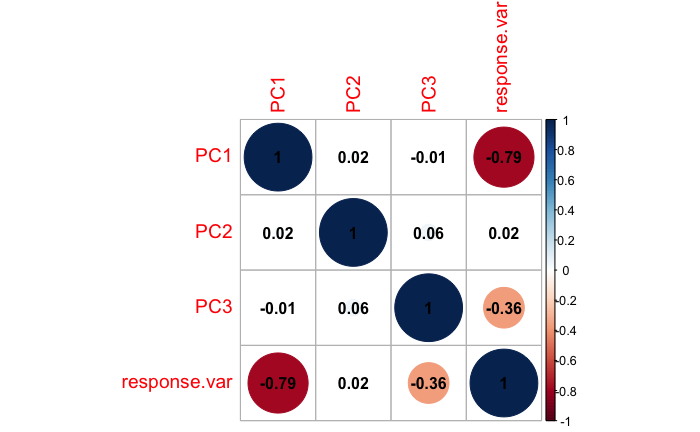

```r
corrplot::corrplot(pc.cor, method="circle", addCoef.col = 1, tl.cex = 1.2)
```

```r
#highly.cor <- caret::findCorrelation(stress.cor, cutoff = .75)
#fit.filtered <- fit.df[,-highly.cor]
fit <- stats::lm(response.var ~ ., data=fit.df)
fit2 <- stats::lm(response.var ~ ., data=fit.df[c("PC1", "PC3", "response.var")])
summary(fit)
```

```
Call:
stats::lm(formula = response.var ~ ., data = fit.df)

Residuals:
     Min       1Q   Median       3Q      Max
-2.09689 -0.45126  0.00986  0.35999  1.53491

Coefficients:
             Estimate Std. Error t value Pr(>|t|)
(Intercept)  2.312998   0.063112  36.649  < 2e-16 ***
PC1         -0.034496   0.002259 -15.271  < 2e-16 ***
PC2          0.003000   0.002790   1.075    0.285
PC3         -0.024068   0.003392  -7.096 2.72e-10 ***
---
Signif. codes:  0 ‘***’ 0.001 ‘**’ 0.01 ‘*’ 0.05 ‘.’ 0.1 ‘ ’ 1

Residual standard error: 0.6142 on 91 degrees of freedom
Multiple R-squared:  0.7562,    Adjusted R-squared:  0.7481
F-statistic: 94.07 on 3 and 91 DF,  p-value: < 2.2e-16
```

```r
summary(fit2)
```

```
Call:
stats::lm(formula = response.var ~ ., data = fit.df[c("PC1",
    "PC3", "response.var")])

Residuals:
     Min       1Q   Median       3Q      Max
-2.42722 -0.43220  0.04599  0.35458  1.66063

Coefficients:
             Estimate Std. Error t value Pr(>|t|)
(Intercept)  2.316627   0.063076  36.728  < 2e-16 ***
PC1         -0.034436   0.002260 -15.237  < 2e-16 ***
PC3         -0.023855   0.003389  -7.039 3.39e-10 ***
---
Signif. codes:  0 ‘***’ 0.001 ‘**’ 0.01 ‘*’ 0.05 ‘.’ 0.1 ‘ ’ 1

Residual standard error: 0.6147 on 92 degrees of freedom
Multiple R-squared:  0.7531,    Adjusted R-squared:  0.7477
F-statistic: 140.3 on 2 and 92 DF,  p-value: < 2.2e-16
```

```r
#car::avPlots(fit, marginal.scale=F, id=F)
```

```r
layout(matrix(c(1,2,3,4),2,2,byrow=T))
plot(fit$fitted.values, rstudent(fit),
 main="Multi Fit Studentized Residuals",
 xlab="Predictions",ylab="Studentized Resid",
 ylim=c(-2.5,2.5))
abline(h=0, lty=2)
```

```r
plot(fit.df$PC1, fit$resid,
 main="Residuals by PC1",
 xlab="PC1",ylab="Residuals")
abline(h=0,lty=2)
```

```r
hist(fit$resid, main="Histogram of Residuals")
qqnorm(fit$resid)
```

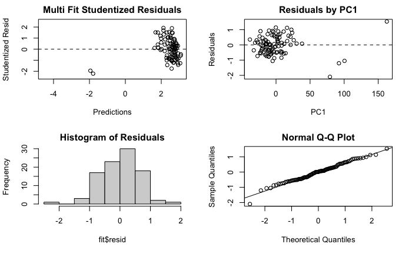

```r
qqline(fit$resid)
```

```r
plot(fit)
```

Sequentially add additional PCs and calcualte var explained (analogous to protein features)

```r
varExplained <- function(PC, response.df, y) {
  list.var.exp <- list()
  for (i in 1:(ncol(PC))) {
    var.data <- cbind(dplyr::select(PC, c(1:i)), dplyr::select(response.df, c("response.var")))
    fit <- stats::lm(response.var ~ ., data=var.data ) %>% summary()
    list.var.exp[[i]] <- data.table(num.var=i, var.exp=fit$adj.r.squared)
  }
  return(list.var.exp)
}
```

```r
y.nmol <- CHO96[-96, c("sample_ID", "Total.purified.protein_stock1..stock2_nmol")] %>%
  mutate(response.var=log10(Total.purified.protein_stock1..stock2_nmol + 0.001))
y.mg <- CHO96[-96, c("sample_ID", "Total.purified.protein_stock1.stock2_microg")] %>%
  mutate(response.var=log10(Total.purified.protein_stock1.stock2_microg + 0.001))
PC.var <- as.data.frame(res.pca$x[-96,-96])
identical(y.nmol$sample_ID, rownames(PC.var))
```

```
[1] TRUE
```

```r
identical(y.mg$sample_ID, rownames(PC.var))
```

```
[1] TRUE
```

```r
df.var.exp <- varExplained(PC=PC.var, response.df = y.mg) %>% bind_rows()
```

```
Using an external vector in selections was deprecated in tidyselect 1.1.0.
```

[figure not shown]

ENRICHMENT of most variable genes ############################################################

If you want to only look at producing clones

```r
subset.status <- c("highest cell count", "highest viability", "highest amount", "lowest amount", "lowest viability", "lowest cell count")
#TPM.log_subset <- subset(TPM.log, select=c("gene",CHO96$sample_ID[CHO96$group.info %in% subset.status]))
TPM.log_subset <- subset(TPM.log, select=c("gene",CHO96$sample_ID[!(CHO96$group.info %in% c("no amount", "WT"))]))

TPM.log_subset$sds <- matrixStats::rowSds(as.matrix(TPM.log_subset[, -c("gene")]))
TPM.log_subset <- TPM.log_subset %>% dplyr::arrange(desc(sds))
```

```r
enrich.varGenes <- function(topVar, sortGeneList, gene.map) {
  top.CHO <- sortGeneList[1:topVar]
  universe.CHO <- sortGeneList
  top.human <- gene.map$humanID[gene.map$choSymbol %in% top.CHO]
  universe.human <- gene.map$humanID[gene.map$choSymbol %in% sortGeneList]

  ## GO BP enrichmnet
  set.seed(18)
  eGO.BP <- enrichGO(gene = as.character(top.human),
                  universe = as.character(universe.human),
                  OrgDb = org.Hs.eg.db,
                  keyType = 'ENTREZID',
                  minGSSize = 10,
                  ont = "BP",
                  pAdjustMethod = "BH",
                  pvalueCutoff = 0.01,
                  qvalueCutoff = 0.05,
                  readable = T) %>% clusterProfiler::simplify(cutoff = 0.7, by="p.adjust", select_fun=min)

  ## GO MF enrichmnet
  set.seed(18)
  eGO.MF <- enrichGO(gene = as.character(top.human),
                  universe = as.character(universe.human),
                  OrgDb = org.Hs.eg.db,
                  keyType = 'ENTREZID',
                  minGSSize = 10,
                  ont = "MF",
                  pAdjustMethod = "BH",
                  pvalueCutoff = 0.01,
                  qvalueCutoff = 0.05,
                  readable = T) %>% clusterProfiler::simplify(cutoff = 0.7, by="p.adjust", select_fun=min)

  ## GO CC enrichmnet
  set.seed(18)
  eGO.CC <- enrichGO(gene = as.character(top.human),
                  universe = as.character(universe.human),
                  OrgDb = org.Hs.eg.db,
                  keyType = 'ENTREZID',
                  minGSSize = 10,
                  ont = "CC",
                  pAdjustMethod = "BH",
                  pvalueCutoff = 0.01,
                  qvalueCutoff = 0.05,
                  readable = T) %>% clusterProfiler::simplify(cutoff = 0.7, by="p.adjust", select_fun=min)

  ## KEGG enrichment
  set.seed(18)
  eKEGG <- enrichKEGG(gene = as.character(top.human),
                  universe = as.character(universe.human),
                  organism = 'hsa',
                  minGSSize = 10,
                  pvalueCutoff = 0.05,
                  pAdjustMethod = "BH")

  ## Reactome enrichment
  set.seed(18)
  eReactome <- enrichPathway(gene = as.character(top.human),
                  universe = as.character(universe.human),
                  organism = 'human',
                  minGSSize = 10,
                  pvalueCutoff = 0.05,
                  pAdjustMethod = "BH")

  eRes.df <- list(GO.BP=data.table(eGO.BP@result)[p.adjust <= 0.01 ,], GO.MF=data.table(eGO.MF@result)[p.adjust <= 0.01 ,],
    GO.CC=data.table(eGO.CC@result)[p.adjust <= 0.01 ,],
    KEGG=data.table(eKEGG@result)[p.adjust <= 0.01 ,],
    Reactome=data.table(eReactome@result)[p.adjust <= 0.01 ,]) %>% rbindlist(idcol=T, fill=T)


  missing <- length(setdiff(top.CHO, gene.map$choSymbol))
  message(sprintf("Warning: Unable to map %1.0f of the top %1.0f varibale genes.", missing, topVar))

  return(eRes.df)
}
```

```r
enrich.res <- enrich.varGenes(topVar=500, sortGeneList=TPM.log_subset$gene, gene.map=CHO.human_map)
```

```r
#fwrite(enrich.res, "Output/210712_varEnrichment.csv")
```

Correaltion between top var expression and titers

```r
top.var <- TPM.log_subset[1:500, 2:92] %>% as.data.frame() %>% `rownames<-`(TPM.log_subset$gene[1:500])
response.var <- CHO96[CHO96$sample_ID %in% colnames(top.var), c("sample_ID", "Total.purified.protein_stock1.stock2_microg", "Total.purified.protein_stock1..stock2_nmol")]
identical(colnames(top.var), response.var$sample_ID)

corGenes <- function(x,y) {
  res <- cor.test(x,y, method="spearman")
  res.df <- data.frame(rho=res$estimate, pval=res$p.value)
  return(res.df)
}


geneCorr <- apply(as.matrix(top.var), 1, corGenes, y=response.var$Total.purified.protein_stock1.stock2_microg)  %>% rbindlist(idcol=T, fill=T) %>%
  dplyr::rename("gene"=".id") %>% mutate(padj=p.adjust(pval, method="BH")) %>% left_join(CHO.human_map, by=c("gene"="choSymbol"))
```

```r
View(left_join(TPM.log[, c("gene", "sds")], CHO.human_map[, c("choSymbol", "humanSymbol")], by=c("gene"="choSymbol")))

View(left_join(TPM.log_subset[, c("gene", "sds")], CHO.human_map[, c("choSymbol", "humanSymbol")], by=c("gene"="choSymbol")))
```

```r
#saveRDS(list(TPM.log=TPM.log, pheno.data=CHO96, CHO.human_map=CHO.human_map), "Output/list.TPM_pheno_map.RDS")
```

GSEA between phenotypic groups ############################################################

group.info2== producers vs non-producers (including WT) group.info3== producers vs non-producers vs WT-pheno (WT and FLT3LG) group.info4== producers vs non-producers (excluding WT)

```r
#rm(col.data)
#col.data <- data.table(CHO96[, c("sample_ID", "genes", "amount_microgram")])
#col.data[, group.info2:="producer"][amount_microgram=="no amount"|genes=="WT", group.info2:="non-producer"][, group.info3:="producer"][amount_microgram=="no amount", group.info3:="non-producer"][genes=="WT"|genes=="FLT3LG", group.info3:="WT-pheno"]
#col.data$group.info4 <- c(col.data$group.info2[1:95], "WT")
#col.data[is.na(col.data)] <- ""

col.data <- openxlsx::read.xlsx("Output/GSEA/colData.xlsx")
col.data[is.na(col.data)] <- ""
#txi.trim <- lapply(txi.cho[1:3], function(x) {as.data.frame(x) %>% filter(rownames(x) %in% TPM.log$gene)})
txi.trim <- lapply(txi.cho[1:3], function(x) {x[rownames(x) %in% TPM.log$gene ,]})
txi.trim[["countsFromAbundance"]] <- txi.cho$countsFromAbundance
```

Differential expression amount (lowest vs highest)

```r
identical(colnames(txi.trim$abundance), col.data$sample_ID)
dds <- DESeqDataSetFromTximport(txi.trim, colData = col.data, design= ~amount_microgram)

nrow(dds)
keep <- rowSums(counts(dds)) > 1
dds <- dds[keep,]
nrow(dds)

set.seed(18)
dds <- DESeq(dds)

res.amount <- DESeq2::results(dds, contrast=c("amount_microgram", "lowest amount", "highest amount")) %>% as.data.frame() %>% rownames_to_column(var="gene")
```

Differential expression: group.info2== non-producers (including WT) vs producers

```r
dds.prod <- DESeqDataSetFromTximport(txi.trim, colData = col.data, design= ~ group.info2)

nrow(dds.prod)
keep <- rowSums(counts(dds.prod)) > 1
dds.prod <- dds.prod[keep,]
nrow(dds.prod)

set.seed(18)
dds.prod <- DESeq(dds.prod)

res.nonProd <- DESeq2::results(dds.prod, contrast=c("group.info2", "non-producer", "producer")) %>% as.data.frame() %>% rownames_to_column(var="gene")
```

Differential expression: group.info4== producers vs non-producers (excluding WT)

```r
dds.group4 <- DESeqDataSetFromTximport(txi.trim, colData = col.data, design= ~ group.info4)

nrow(dds.group4)
keep <- rowSums(counts(dds.group4)) > 1
dds.group4 <- dds.group4[keep,]
nrow(dds.group4)

set.seed(18)
dds.group4 <- DESeq(dds.group4)

res.nonProd_exWT <- DESeq2::results(dds.group4, contrast=c("group.info4", "non-producer", "producer")) %>% as.data.frame() %>% rownames_to_column(var="gene")
```

Differential expression: group.info3 non-producers WT pheno (WT-pheno) vs producer

```r
identical(colnames(txi.trim$abundance), col.data$sample_ID)
dds <- DESeqDataSetFromTximport(txi.trim, colData = col.data, design= ~group.info3)

nrow(dds)
keep <- rowSums(counts(dds)) > 1
dds <- dds[keep,]
nrow(dds)

set.seed(18)
dds <- DESeq(dds)

res.np_WT <- DESeq2::results(dds, contrast=c("group.info3", "WT-pheno", "producer")) %>% as.data.frame() %>% rownames_to_column(var="gene")
```

Differential expression: group.info3 non-producers WT pheno (non-producer) vs producers

```r
identical(colnames(txi.trim$abundance), col.data$sample_ID)
dds <- DESeqDataSetFromTximport(txi.trim, colData = col.data, design= ~group.info3)

nrow(dds)
keep <- rowSums(counts(dds)) > 1
dds <- dds[keep,]
nrow(dds)

set.seed(18)
dds <- DESeq(dds)

res.np <- DESeq2::results(dds, contrast=c("group.info3", "non-producer", "producer")) %>% as.data.frame() %>% rownames_to_column(var="gene")
```

```r
saveRDS(list(low_vs_high=res.amount, non_vs_prod_exWT=res.nonProd_exWT, non_vs_prod_incWT=res.nonProd, npWT_vs_prod=res.np_WT, np_vs_prod=res.np), "Output/DEanalysis/101422_DESeq2.RDS")
```

```r
res.amount.sig <- res.amount %>% subset(padj<=0.05 & abs(log2FoldChange)>= log2(1.5)) %>% arrange(desc(abs(log2FoldChange))) %>%
  left_join(CHO.human_map, by=c("gene"="choSymbol"))
res.nonProd.sig <- res.nonProd %>% subset(padj<=0.05 & abs(log2FoldChange)>= log2(1.5)) %>% arrange(desc(abs(log2FoldChange))) %>%
  left_join(CHO.human_map, by=c("gene"="choSymbol"))
res.nonProd_exWT.sig <- res.nonProd_exWT %>% subset(padj<=0.05 & abs(log2FoldChange)>= log2(1.5)) %>% arrange(desc(abs(log2FoldChange))) %>%
  left_join(CHO.human_map, by=c("gene"="choSymbol"))
```

```r
DESeq.gsea <- function(dds.res, thresh) {
  dds.map <- left_join(dds.res, CHO.human_map, by=c("gene"="choSymbol")) %>% drop_na(humanID) %>% arrange(desc(log2FoldChange))
  gene.list <- dds.map$log2FoldChange %>% setNames(dds.map$humanSymbol) #%>% arrange(Log2FoldChange)

  set.seed(18)
  gseaGO.BP <- gseGO(geneList = gene.list,
                         ont="BP",
                         keyType = "SYMBOL",
                         OrgDb = org.Hs.eg.db,
                         minGSSize = 8,
                         pvalueCutoff = 0.05,
                         pAdjustMethod = "BH") %>% clusterProfiler::simplify(cutoff = thresh, by="p.adjust", select_fun=min)
  set.seed(18)
  gseaGO.MF <- gseGO(geneList = gene.list,
                         ont="MF",
                         keyType = "SYMBOL",
                         OrgDb = org.Hs.eg.db,
                         minGSSize = 8,
                         pvalueCutoff = 0.05,
                         pAdjustMethod = "BH") %>% clusterProfiler::simplify(cutoff = thresh, by="p.adjust", select_fun=min)
  set.seed(18)
  gseaGO.CC <- gseGO(geneList = gene.list,
                         ont="CC",
                         keyType = "SYMBOL",
                         OrgDb = org.Hs.eg.db,
                         minGSSize = 8,
                         pvalueCutoff = 0.05,
                         pAdjustMethod = "BH") %>% clusterProfiler::simplify(cutoff = thresh, by="p.adjust", select_fun=min)
  set.seed(18)
  gseaReactome <- gsePathway(geneList = gene.list %>% setNames(dds.map$humanID),
                             organism = 'human',
                             minGSSize = 10,
                             pvalueCutoff = 0.05,
                             pAdjustMethod = "BH")
  set.seed(18)
  gseaKEGG <- gseKEGG(geneList = gene.list %>% setNames(dds.map$humanID),
                     organism = 'hsa',
                  minGSSize = 10,
                  pvalueCutoff = 0.05,
                  pAdjustMethod = "BH")
  gseaRes.df <- list(GO.BP=data.table(gseaGO.BP@result)[p.adjust <= 0.01 ,], GO.MF=data.table(gseaGO.MF@result)[p.adjust <= 0.01 ,],
    GO.CC=data.table(gseaGO.CC@result)[p.adjust <= 0.01 ,],
    KEGG=data.table(gseaKEGG@result)[p.adjust <= 0.01 ,],
    Reactome=data.table(gseaReactome@result)[p.adjust <= 0.01 ,]) %>% rbindlist(idcol=T, fill=T)

  return(gseaRes.df)

}
```

```r
sim.thresh=0.7
gsea.amount <- DESeq.gsea(res.amount, sim.thresh)
gsea.nonProd <- DESeq.gsea(res.nonProd, sim.thresh)
gsea.nonProd_exWT <- DESeq.gsea(res.nonProd_exWT, sim.thresh)
gsea.np_WT <- DESeq.gsea(res.np_WT, sim.thresh)
gsea.np <- DESeq.gsea(res.np, sim.thresh)
```

common between non and low producers

```r
intersect(gsea.amount$ID, gsea.nonProd_exWT$ID) %>% length()
intersect(gsea.amount$ID[gsea.amount$NES >0], gsea.nonProd_exWT$ID[gsea.nonProd_exWT$NES>0]) %>% length()
intersect(gsea.amount$ID[gsea.amount$NES <0], gsea.nonProd_exWT$ID[gsea.nonProd_exWT$NES<0]) %>% length()

gsea.common <- inner_join(gsea.amount %>% setNames(paste0(names(gsea.amount), "_amount")),
                          gsea.nonProd_exWT %>% setNames(paste0(names(gsea.nonProd_exWT), "_nonProd")),
                          by=c("ID_amount"="ID_nonProd"))
```

unique among non and low producers

```r
setdiff(gsea.nonProd_exWT$ID, gsea.amount$ID) %>% length()
setdiff(gsea.amount$ID, gsea.nonProd_exWT$ID) %>% length()

gsea.unique_nonProd <- gsea.nonProd_exWT[!gsea.nonProd_exWT$ID %in% gsea.amount$ID ,]
gsea.unique_amount <- gsea.amount[!gsea.amount$ID %in% gsea.nonProd_exWT$ID ,]
```

```r
gsea.list <- list(amount=gsea.amount, nonProd_exWT=gsea.nonProd_exWT, nonProd=gsea.nonProd,
                  common=gsea.common, unique_nonProd_exWT=gsea.unique_nonProd, unique_amount=gsea.unique_amount,
                  np_WT=gsea.np_WT, np=gsea.np)
openxlsx::write.xlsx(gsea.list, "Output/GSEA/221014_GSEAresults.xlsx")
```

```r
saveRDS(list(nonProd=res.nonProd %>% left_join(CHO.human_map, by=c("gene"="choSymbol")),
             amount=res.amount %>% left_join(CHO.human_map, by=c("gene"="choSymbol")),
             nonProd.exWT= res.group4 %>% left_join(CHO.human_map, by=c("gene"="choSymbol")),
             np_WT=res.np_WT %>% left_join(CHO.human_map, by=c("gene"="choSymbol")),
             np=res.np %>% left_join(CHO.human_map, by=c("gene"="choSymbol"))
             ), "Output/GSEA/DESeq_results.RDS")
```

Perform hypergeometric enrichment of sig genes different between producers and non producers (excluding WT)

```r
enrich.group4 <- enrich.varGenes(topVar=nrow(res.group4.sig), sortGeneList=c(res.group4.sig$gene, res.group4$gene[!(res.group4$gene %in% res.group4.sig$gene)]), gene.map=CHO.human_map)
```

```r
WT.specific <- setdiff(gsea.nonProd$Description, gsea.group4$Description)
nonProd.specific <- setdiff(gsea.group4$Description, gsea.nonProd$Description)
overlap <- intersect(gsea.nonProd$Description, gsea.group4$Description)
```

Compare nonProd (inc WT) vs prod AND low vs high

```r
setdiff(gsea.nonProd[NES > 0 , Description], gsea.amount[NES>0, Description])
setdiff(gsea.amount[NES>0, Description], gsea.nonProd[NES > 0 , Description])

# terms with negative NES
setdiff(gsea.nonProd[NES < 0 , Description], gsea.amount[NES<0, Description])
setdiff(gsea.amount[NES<0, Description], gsea.nonProd[NES < 0 , Description])
```

plot interesting results

```r
#subset.interesting <- openxlsx::read.xlsx("Output/220102_DEgsea_subset.xlsx", sheet="amount_subset")
subset.interesting <- openxlsx::read.xlsx("Output/GSEA/GSEA_Table.xlsx", sheet="amount_subset")
subset.interesting<- subset.interesting[order(nrow(subset.interesting):1) ,]
subset.interesting$Description <- factor(subset.interesting$Description, levels=subset.interesting$Description)

lab.col <- RColorBrewer::brewer.pal(length(unique(subset.interesting$Category)), "Set2")[network::as.color(subset.interesting$Category)]
## barplot
ggplot(subset.interesting, # you can replace the numbers to the row number of pathway of your interest
       aes(x = NES, y = Description)) +
  geom_col(aes(fill = p.adjust)) +
  theme_bw(base_size = 20) +
  scale_fill_gradient(limits=c(0, 0.01), low="red", high="blue") +
  ylab(NULL) +
  labs(title="GSEA", subtitle="low producers vs. high producers") +
  theme(axis.text.y = element_text(colour = lab.col)) +
  theme(legend.justification = "top")
```

Dummy plot to get color legend for term categories

```r
df <- data.frame(val=rep(4:1), cat=unique(subset.interesting$Category), color=c("#66C2A5", "#FC8D62", "#8DA0CB", "#E78AC3"), dummy=rep("",4)) %>%
  mutate(Category = glue::glue("<span style='color:{color}'>{cat}</span> {dummy}"), #name = glue::glue("<i style='color:{color}'>{category}</i> {dummy}"
  Category = fct_reorder(Category, val))
ggplot(df, aes(x= Category, y= val, fill=Category)) +
  geom_bar(stat="identity") +
  scale_fill_manual(values=rev(c("#66C2A5", "#FC8D62", "#8DA0CB", "#E78AC3"))) + theme(axis.text.x = ggtext::element_markdown(), legend.text = ggtext::element_markdown(size=20), legend.key.size=unit(0.5, "cm"), legend.key.width = unit(0.25,"cm"), legend.title = element_text(size=20))
  #theme(legend.text = ggtext::element_markdown(color=c("#66C2A5", "#FC8D62", "#8DA0CB", "#E78AC3")), legend.key.size=unit(0.5, "cm"), legend.key.width = unit(0.25,"cm"))
```

```r
subset.interesting <- openxlsx::read.xlsx("Output/GSEA/GSEA_Table.xlsx", sheet="nonProd_subset")
subset.interesting<- subset.interesting[order(nrow(subset.interesting):1) ,]
subset.interesting$Description <- factor(subset.interesting$Description, levels=subset.interesting$Description)

lab.col <- RColorBrewer::brewer.pal(length(unique(subset.interesting$Category)), "Set2")[network::as.color(subset.interesting$Category)]
## barplot
ggplot(subset.interesting, # you can replace the numbers to the row number of pathway of your interest
       aes(x = NES, y = Description)) +
  geom_col(aes(fill = p.adjust)) +
  theme_bw(base_size = 20) +
  scale_fill_gradient(limits=c(0, 0.01), low="red", high="blue") +
  ylab(NULL) +
  labs(title="GSEA", subtitle="non-producers vs. producers") +
  theme(axis.text.y = element_text(colour = lab.col)) +
  theme(legend.justification = "top")
```

FURIN_1(P6975_159, 79) vs FURNIN_2 (P6975_189, 455)

```r
furins <- TPM.log[, c("gene", "P6975_159", "P6975_189")][, L2FC:= P6975_159-P6975_189] %>% dplyr::rename("FURIN_1"="P6975_159") %>%
  dplyr::rename("FURIN_2"="P6975_189") %>% left_join(CHO.human_map, by=c("gene"="choSymbol")) %>% arrange(desc(abs(L2FC)))

pheno.vars <- c("genes", "Process.type", "Total.purified.protein_stock1.stock2_microg", "amount_microgram", "Cell.conc.harvest", "Viability.harvest.%")
furins.pheno <- CHO96[, ..pheno.vars][, cell.count:= CHO96$`Cell.conc.(harvest)` * CHO96$`Harvest.volume.[ml]`] %>% filter(genes=="FURIN_1" | genes=="FURIN_2")
```

```r
LFC.symbol <- furins$L2FC[!is.na(furins$humanSymbol)] %>% setNames(furins$humanSymbol[!is.na(furins$humanSymbol)])
LFC.entrez <- furins$L2FC[!is.na(furins$humanID)] %>% setNames(furins$humanID[!is.na(furins$humanID)]) %>% na.omit()

gsea.furin <- list()
gsea.furin[["GO.BP"]] <- gseGO(geneList = LFC.symbol,
                         ont="BP",
                         keyType = "SYMBOL",
                         OrgDb = org.Hs.eg.db,
                         minGSSize = 8,
                         pvalueCutoff = 0.05,
                         pAdjustMethod = "BH") %>% clusterProfiler::simplify(cutoff = 0.7, by="p.adjust", select_fun=min) %>%
  as.data.frame %>%
  dplyr::filter(p.adjust <= 0.01)

gsea.furin[["GO.MF"]] <- gseGO(geneList = LFC.symbol,
                         ont="MF",
                         keyType = "SYMBOL",
                         OrgDb = org.Hs.eg.db,
                         minGSSize = 8,
                         pvalueCutoff = 0.05,
                         pAdjustMethod = "BH") %>% clusterProfiler::simplify(cutoff = 0.7, by="p.adjust", select_fun=min) %>%
  as.data.frame %>%
  dplyr::filter(p.adjust <= 0.01)

gsea.furin[["GO.CC"]] <- gseGO(geneList = LFC.symbol,
                         ont="CC",
                         keyType = "SYMBOL",
                         OrgDb = org.Hs.eg.db,
                         minGSSize = 8,
                         pvalueCutoff = 0.05,
                         pAdjustMethod = "BH") %>% clusterProfiler::simplify(cutoff = 0.7, by="p.adjust", select_fun=min) %>%
  as.data.frame %>%
  dplyr::filter(p.adjust <= 0.01)

gsea.furin[["Reactome"]] <- gsePathway(geneList = LFC.entrez,
                             organism = 'human',
                             minGSSize = 10,
                             pvalueCutoff = 0.05,
                             pAdjustMethod = "BH") %>%
  as.data.frame %>%
  dplyr::filter(p.adjust <= 0.01)

gsea.furin[["KEGG"]] <- gseKEGG(geneList = LFC.entrez,
                     organism = 'hsa',
                  minGSSize = 10,
                  pvalueCutoff = 0.05,
                  pAdjustMethod = "BH") %>%
  as.data.frame %>%
  dplyr::filter(p.adjust <= 0.01)

gsea.furin.df <- rbindlist(gsea.furin, idcol=T, fill=T)
```

Density plot of high vs low producers

```r
plot.data <- data.table(CHO96[1:91 ,]) %>% mutate(log.yield=log10(Total.purified.protein_stock1.stock2_microg))
# high = "#F8766D"
# low = "#00BA38"

ggplot(plot.data, aes(x=log.yield, fill=as.factor(amount_microgram))) + geom_density(alpha=0.4) +
  labs(fill = "Protein yield") + xlab("log10 abundance (μg)") + theme_bw() + theme(text=element_text(size=15)) +
  scale_fill_manual( values = c("#F8766D","#00BA38"))
```

Hierarchical clustering

```r
set.seed(18)

heatmap.TPM <- TPM.log[, -c("gene", "sds")] %>% `rownames<-`(TPM.log$gene) %>%
  `colnames<-`(CHO96$genes) %>% as.data.frame()
pheatmap::pheatmap(heatmap.TPM,
                   main="Hierarchical clustering using TPM",
                   scale="row",
                   border_color = NA,
                   #cluster.cols = hclust(dist(cellfie.matrix, method="euclidean"), method="complete"),
                   clustering_distance_cols = "correlation",
                   clustering_method = "complete",
                   annotation_col = data.frame(amount=CHO96$amount_microgram) %>% `rownames<-`(CHO96$genes),
                   show_colnames = T,
                   show_rownames = F,
                   treeheight_row = 0,
                   legend_breaks = c(0,1)
                   )

set.seed(18)

heatmap.topVar <- TPM.log[1:500, 2:97] %>% as.data.frame() %>% `rownames<-`(TPM.log$gene[1:500]) %>% `colnames<-`(CHO96$genes)
pheatmap::pheatmap(heatmap.topVar,
                   main="Hierarchical clustering using top variable TPM",
                   scale="row",
                   border_color = NA,
                   #cluster.cols = hclust(dist(cellfie.matrix, method="euclidean"), method="complete"),
                   clustering_distance_cols = "correlation",
                   clustering_method = "complete",
                   annotation_col = data.frame(amount=CHO96$amount_microgram) %>% `rownames<-`(CHO96$genes),
                   show_colnames = T,
                   show_rownames = F,
                   #treeheight_row = 0,
                   legend_breaks = c(0,1)
                   )
```

```r
#PSIM <- openxlsx::read.xlsx("Data/protFeatures/PSIM_matrix.xlsx", sheet="Human")
PSIM <- openxlsx::read.xlsx("Data/protFeatures/pone.0063284.s012.xlsx")
PSIM.96 <- inner_join(PSIM, subset(CHO96, select=c("genes", "Uniprot.ID", "amount_microgram", "Total.purified.protein_stock1.stock2_microg")), by=c("UniProtID"="Uniprot.ID")) %>%
  dplyr::arrange(Total.purified.protein_stock1.stock2_microg)
```

Plot GSEA between non prod (ex WT) and prod

```r
#subset.interesting <- openxlsx::read.xlsx("Output/220102_DEgsea_subset.xlsx", sheet="amount_subset")
subset.interesting <- openxlsx::read.xlsx("Output/GSEA/221014_GSEAresults_HMedits.xlsx", sheet="nonProd_exWT_HM")
subset.interesting<- subset.interesting[order(nrow(subset.interesting):1) ,]
subset.interesting$Description <- factor(subset.interesting$Description, levels=subset.interesting$Description)

lab.col <- RColorBrewer::brewer.pal(length(unique(subset.interesting$Category)), "Dark2")[network::as.color(subset.interesting$Category)]
## barplot
gsea.plot <- ggplot(subset.interesting, # you can replace the numbers to the row number of pathway of your interest
       aes(x = NES, y = Description)) +
  geom_col(aes(fill = p.adjust)) +
  theme_bw(base_size = 20) +
  scale_fill_gradient(limits=c(0, 0.01), low="red", high="blue") +
  ylab(NULL) +
  labs(title="GSEA", subtitle="failed vs. successful producers") +
  theme(axis.text.y = element_text(colour = lab.col)) +
  theme(legend.justification = "top")
ggsave("Figures/GSEA_plot.svg", gsea.plot, width = 11, height = 7.5)

## dummy plot to get color legend
df <- data.frame(val=rep(6:1), cat=unique(subset.interesting$Category), color=unique(lab.col), dummy=rep("",6)) %>%
  mutate(Category = glue::glue("<span style='color:{color}'>{cat}</span> {dummy}"),
  Category = fct_reorder(Category, val))

gsea.legend <- ggplot(df, aes(x= Category, y= val, fill=Category)) +
  geom_bar(stat="identity") +
  scale_fill_manual(values=rev(unique(lab.col))) + theme(axis.text.x = ggtext::element_markdown(), legend.text = ggtext::element_markdown(size=20), legend.key.size=unit(0.5, "cm"), legend.key.width = unit(0.25,"cm"), legend.title = element_text(size=20))
ggsave("Figures/GSEA_legend.svg", gsea.legend, width = 11, height = 7.5)
```